# Examining elevation and population distribution of Metro Vancouver Dissemination Areas

Michelle Huang

2026-11-19

## For elevation

Packages used: sf, ggplot2, classInt, dplyr.

```r
library(sf)
library(ggplot2)
library(classInt)
library(dplyr)
```

Reading GeoJSON:

```r
DAs <- st_read('https://michellechuqi.github.io/geos472-group-map/maps/zonal01.geojson')
```

Examining elevation distribution. Note that elevation unit is metres above mean sea level.

```r
summary(DAs$elevation)
```

```
   Min. 1st Qu.  Median    Mean 3rd Qu.    Max.
   0.00   21.00   58.00   61.72   90.00  255.00
```

Elevation distribution visualised via histogram:

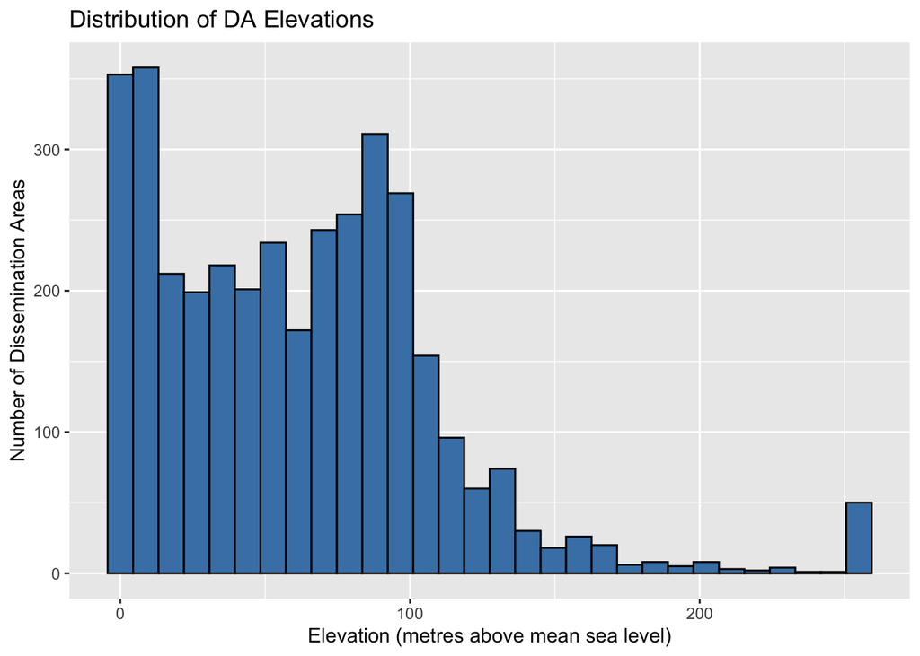

```r
ggplot(DAs, aes(x = elevation)) +
  geom_histogram(
    bins = 30,
    fill = "steelblue",
    colour = "black"
  ) +
  labs(
    title = "Distribution of DA Elevations",
    x = "Elevation (metres above mean sea level)",
    y = "Number of Dissemination Areas"
  )
```

Are DAs with no elevation data categorised as NA or 255?

```r
sum(is.na(DAs$elevation))
```

```
[1] 0
```

```r
sum(DAs$elevation == 255)
```

```
[1] 50
```

There are 50 DAs with an elevation value of 255, aka with no elevation value available. The DA with the highest actual elevation value is 247.

Calculating natural breaks ranges for 5 classes:

```r
nb_elevation <- classIntervals(DAs$elevation, n = 5, style = 'jenks')
nb_elevation$brks
```

```
[1]   0  30  69 112 187 255
```

## For population

Summary statistics:

```r
summary(DAs$population)
```

```
   Min. 1st Qu.  Median    Mean 3rd Qu.    Max.
    0.0   486.0   606.0   736.2   812.8  8800.0
```

Distribution of population via histogram:

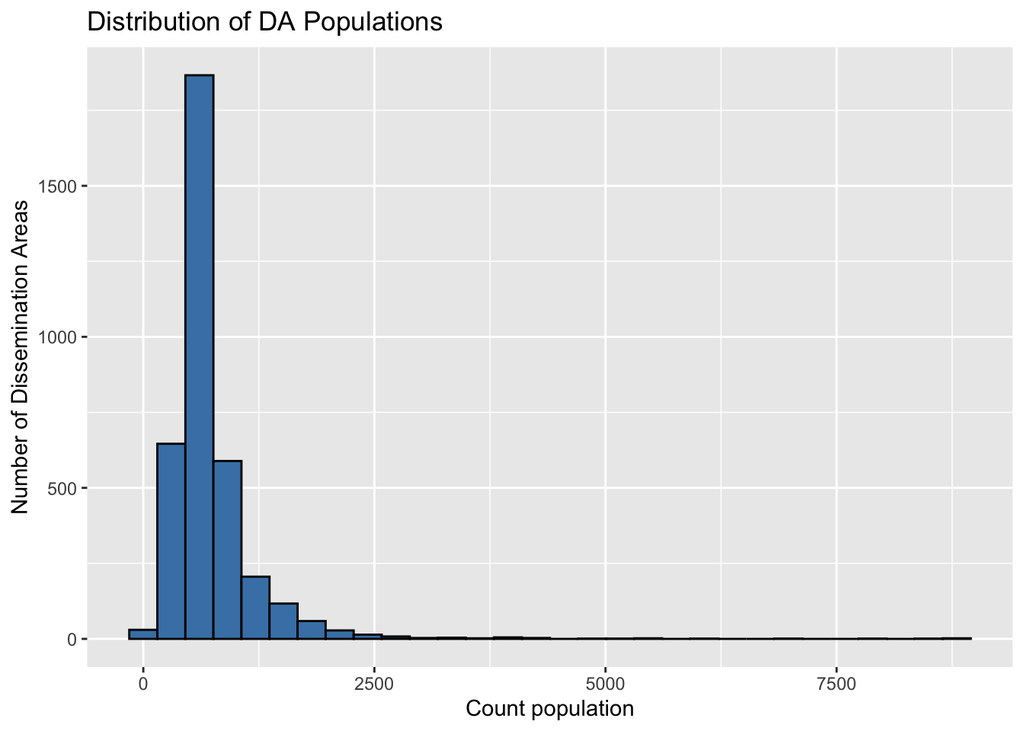

```r
ggplot(DAs, aes(x = population)) +
  geom_histogram(
    bins = 30,
    fill = "steelblue",
    colour = "black"
  ) +
  labs(
    title = "Distribution of DA Populations",
    x = "Count population",
    y = "Number of Dissemination Areas"
  )
```

via boxplot:

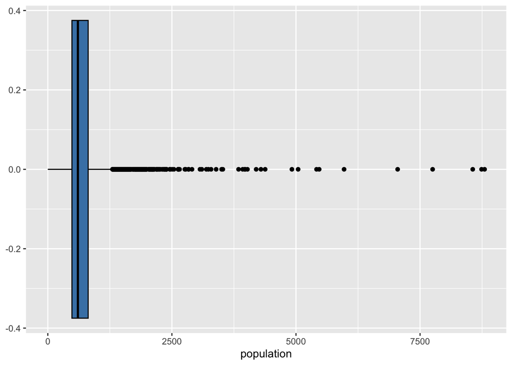

```r
ggplot(DAs, aes(x=population)) +
  geom_boxplot(fill= 'steelblue', colour = 'black')
```

TO-DO:

- need to remove DAs that are outliers for population because idk why they are above like 1000.

General:

- calculate population DENSITY for Map1
- might need to change how elevation is summarised: from majority to average?
- complete elevation visualisation (Map2?)